# Influence of Ede1 copy number on condensate formation in 3∆ diploid yeast

Last compiled on March 18, 2022

## Experiment

The aim of this experiment was to quickly verify whether the formation of Ede1 condensates in living yeast cells depends on Ede1 concentration.

I made three diploid strains homozygous for the *apl3∆ yap1801∆ yap1802∆* triple adaptor deletion, and differing in Ede1-EGFP copy number: *EDE1-EGFP/EDE1/EGFP*, *EDE1-EGFP/EDE1*, *EDE1-EFGP/ede1∆*.

I took 5-micron z-stacks and manually cropped out single cells using the brightfield channel as a reference to not bias the count. A subjective, but blinded assessment was done for the presence / absence of condensates. ImageJ macro `blindAnalysis` was used to display all cells in random order and with hidden strain information, and to record the binary assessment.

### Strain list

| strain | second_ede1 |
| --- | --- |
| MKY3563 | EDE1-GFP |
| MKY3569 | EDE1 |
| MKY3564 | ede1Δ |

## Results

### Individual datasets

Percentage of cells with condensates for each EDE1-EGFP / second Ede1 allele combination, by dataset.

x: number of cells with condensates, n: total number of analyzed condensates, p: x / n, p_min and p_max: estimates of binomial confidence interval based on sample size, by Wilson’s method.

| second_ede1 | dataset | x | n | p | p_min | p_max |
| --- | --- | --- | --- | --- | --- | --- |
| EDE1-GFP | 1 | 41 | 47 | 0.8723404 | 0.7482606 | 0.9401540 |
| EDE1-GFP | 2 | 52 | 57 | 0.9122807 | 0.8105512 | 0.9619483 |
| EDE1-GFP | 3 | 59 | 61 | 0.9672131 | 0.8881051 | 0.9909621 |
| EDE1 | 1 | 34 | 40 | 0.8500000 | 0.7092768 | 0.9293881 |
| EDE1 | 2 | 45 | 56 | 0.8035714 | 0.6815539 | 0.8866140 |
| EDE1 | 3 | 65 | 67 | 0.9701493 | 0.8975344 | 0.9917753 |
| ede1Δ | 1 | 0 | 42 | 0.0000000 | 0.0000000 | 0.0837988 |
| ede1Δ | 2 | 2 | 54 | 0.0370370 | 0.0102164 | 0.1253518 |
| ede1Δ | 3 | 6 | 70 | 0.0857143 | 0.0398767 | 0.1746567 |

### Averaged datasets

Percentage of cells bearing condensates for each EDE1-EGFP / second Ede1 allelecombination, arithmetic mean ± SD from 3 datasets.

| second_ede1 | mean | sd | n |
| --- | --- | --- | --- |
| EDE1-GFP | 0.9172781 | 0.0476334 | 3 |
| EDE1 | 0.8745736 | 0.0859647 | 3 |
| ede1Δ | 0.0409171 | 0.0429887 | 3 |

### Plot

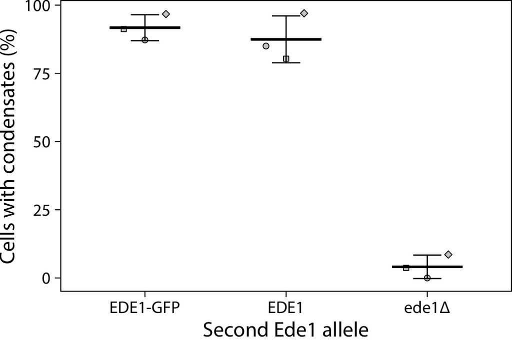

## Source data

### .csv

Download diploid_data.csv

### .RData

Download diploid_data.RData